# Machine Learning II - Group D - MBD16 - Competition

# Instructions

Calling below function after running the RMD file will output a Data Frame with the ‘id’ variable and the prediction for ‘status_group’ including a header for the test dataset that lays on the filepath.

`evaluate('filepath')`

# Table of content

1. Data Exploration
2. Feature Engineering
3. Feature Selection
4. Model Selection

# 1. Data Exploration

Before starting engineering the features, the dataset is explored by plotting relevant features.

```
FALSE status_group
FALSE              functional functional needs repair          non functional
FALSE                   29034                    3926                   20500
```

```
FALSE status_group
FALSE              functional functional needs repair          non functional
FALSE              0.54309764              0.07343808              0.38346427
```

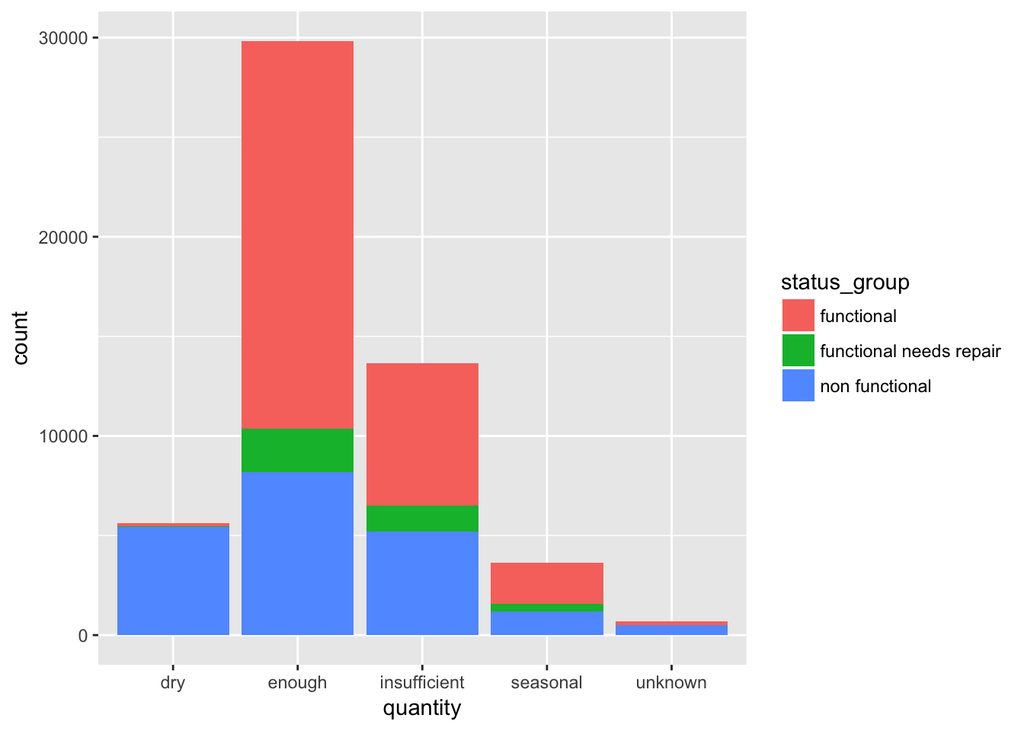

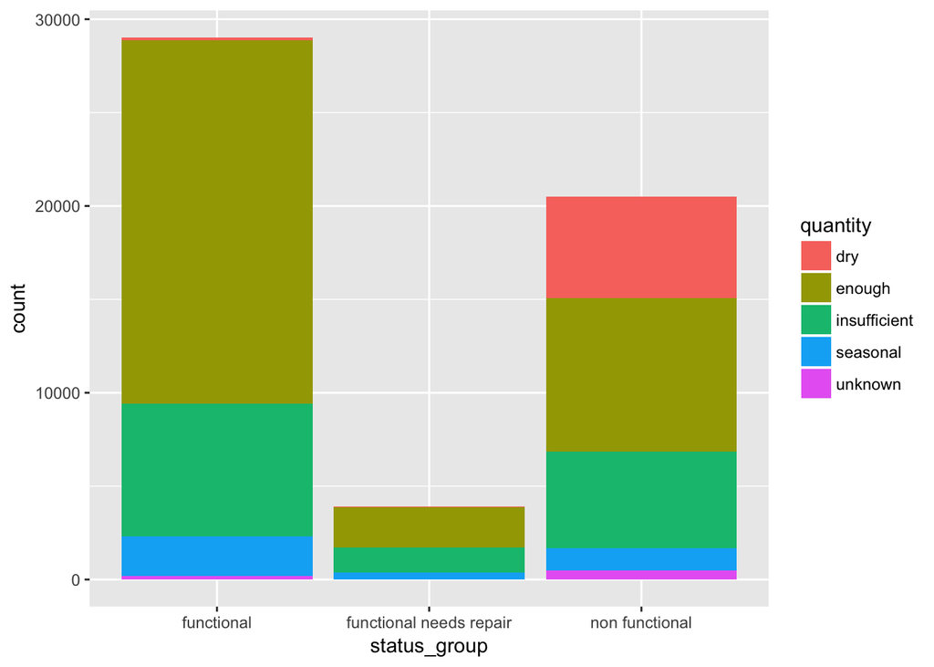

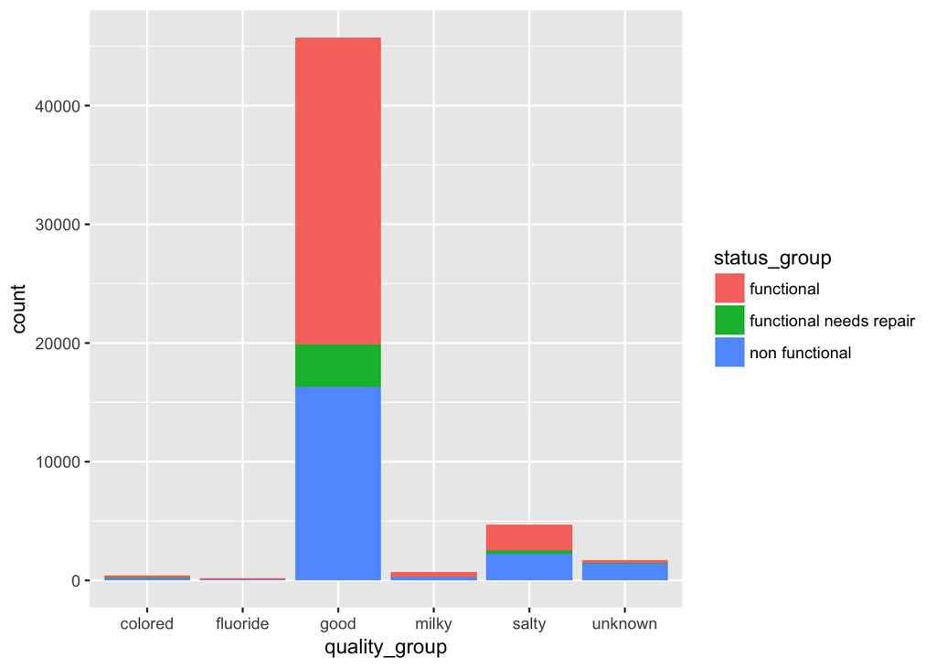

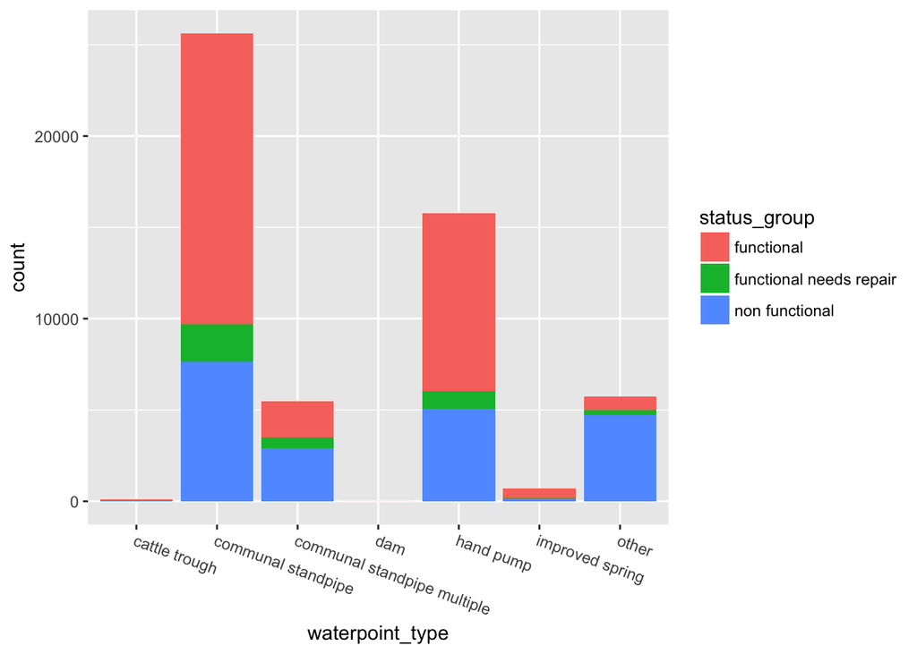

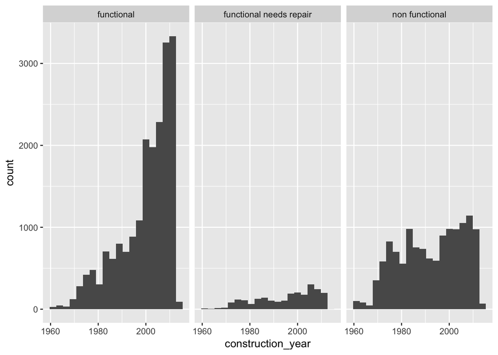

[figure not shown]

Above visualizations help choose relevant features that are possible strong predictors.

# 2. Feature Engineering

An additional feature which represents the number of days since the data was obtained, is created.

Unrealistic, impossible and ‘NA’ values are imputed using mice and random forest.

Reducing factor levels for categorical variables ‘installer’ and ‘funder’. Same values with different name variations are combined to a single level. Rare levels are combined into a single level ‘Others’.

```r
# Converting date to datetime class
finalWP$date_recorded <- as.Date(finalWP$date_recorded)

# Creating new feature from recorded date
finalWP$days_since_last_recorded <- max(finalWP$date_recorded)-finalWP$date_recorded
finalWP$days_since_last_recorded <- as.integer(finalWP$days_since_last_recorded)

# Selecting features with missing values for imputation
impWP <- select(finalWP,id,population,construction_year)
impWP$population[impWP$population == 0] <- NA
impWP$construction_year[impWP$construction_year == 0]<- NA

# Performing mice imputation, based on random forests
# miceMod <- mice(impWP[, !names(impWP) %in% "id"], method="rf")
```

```r
# Generating the completed data
miceOutput <- complete(miceMod)

# Adding imputed values to dataset
finalWP <- select(finalWP,-c(population,construction_year))
finalWP <- cbind(finalWP,miceOutput)

# Converting funder & installer to lowercase
finalWP$funder <- as.character(finalWP$funder)
finalWP$installer <- as.character(finalWP$installer)
chr.cols <- finalWP %>% summarise_each(funs(is.character(.))) %>% unlist() %>% which() %>% names()
finalWP <- finalWP %>% mutate_each(funs(tolower), one_of(chr.cols))

# Installer - reducing factor levels
finalWP$installer <- as.factor(finalWP$installer)
finalWP$installer[finalWP$installer == "" | finalWP$installer == 0 | finalWP$installer == "-"] <- NA
finalWP$installer[finalWP$installer == "gove" | finalWP$installer == "gover" | finalWP$installer == "central government" | finalWP$installer == "central govt"] <- "government"
finalWP$installer[finalWP$installer == "commu"] <- "community"
finalWP$installer[finalWP$installer == "danid"] <- "danida"
finalWP$installer[finalWP$installer == "word" | finalWP$installer == "wo" | finalWP$installer == "word bank" | finalWP$installer == "world" | finalWP$installer == "wordl bank" | finalWP$installer == "would bank" | finalWP$installer == "world banks" | finalWP$installer == "world nk"] <- "world bank"

levels_installer = 11

installerNames <- names(summary(finalWP$installer)[1:levels_installer])
installer <- factor(finalWP$installer, levels=c(installerNames, "Other"))
installer[is.na(installer)] <- "Other"
finalWP$installer <- installer

# Funder - reduce factor levels
finalWP$funder <- as.factor(finalWP$funder)
finalWP$funder[finalWP$funder == "" | finalWP$funder == 0] <- NA

levels_funder = 16

funderNames <- names(summary(finalWP$funder)[1:levels_funder])
funder <- factor(finalWP$funder, levels=c(funderNames, "Other"))
funder[is.na(funder)] <- "Other"
finalWP$funder <- funder

# Imputing missing/incorrect latitudes & longitudes

finalWP$longitude[finalWP$lga =="Bariadi" & finalWP$longitude == 0] <- 34.33104
finalWP$latitude[finalWP$lga =="Bariadi" & finalWP$latitude == -0.00000002] <- -2.69166

finalWP$longitude[finalWP$lga =="Geita" & finalWP$longitude == 0] <- 32.23135
finalWP$latitude[finalWP$lga =="Geita" & finalWP$latitude == -0.00000002] <- -2.88504

finalWP$longitude[finalWP$lga =="Magu" & finalWP$longitude == 0] <- 33.25879
finalWP$latitude[finalWP$lga =="Magu" & finalWP$latitude == -0.00000002] <- -2.45705

# Setting missing values to False
finalWP$public_meeting <- ifelse(finalWP$public_meeting == "TRUE", "True", "False")
finalWP$public_meeting <- as.factor(finalWP$public_meeting)
finalWP$public_meeting[is.na(finalWP$public_meeting)] <- "False"

finalWP$permit <- ifelse(finalWP$permit == "TRUE", "True", "False")
finalWP$permit <- as.factor(finalWP$permit)
finalWP$permit[is.na(finalWP$permit)] <- "False"
```

# 3. Feature Selection

Unneccesary, non-interpretable, constant or unclear features are removed. Feature importance and selection will be handled by random forest in the modeling section.

```r
# Removing redundant features
finalWP <- finalWP[, -which(names(finalWP) == "recorded_by")] # only one value (organization which recorded the information)
finalWP <- finalWP[, -which(names(finalWP) == "quantity_group")] # same as quantity
finalWP <- finalWP[, -which(names(finalWP) == "region_code")] # code for region
finalWP <- finalWP[, -which(names(finalWP) == "date_recorded")] # Date row was entered (not a factor determining functionality)
finalWP <- finalWP[, -which(names(finalWP) == "num_private")] #undefined,id field
finalWP <- finalWP[, -which(names(finalWP) == "district_code")]
finalWP <- finalWP[, -which(names(finalWP) == "quality_group")] #identical to water_quality
finalWP <- finalWP[, -which(names(finalWP) == "payment_type")] # similar to payment
finalWP <- finalWP[, -which(names(finalWP) == "scheme_management")] #similar to management
finalWP <- finalWP[, -which(names(finalWP) == "management_group")] #similar to management
finalWP <- finalWP[, -which(names(finalWP) == "source")] #similiar to source_type
finalWP <- finalWP[, -which(names(finalWP) == "subvillage")] #too many levels
finalWP <- finalWP[, -which(names(finalWP) == "wpt_name")] #too many levels
finalWP <- finalWP[, -which(names(finalWP) == "ward")]
finalWP <- finalWP[, -which(names(finalWP) == "lga")]
finalWP <- finalWP[, -which(names(finalWP) == "scheme_name")]
finalWP <- finalWP[, -which(names(finalWP) == "extraction_type")]
finalWP <- finalWP[, -which(names(finalWP) == "extraction_type_group")]
finalWP <- finalWP[, -which(names(finalWP) == "waterpoint_type_group")]
finalWP <- finalWP[, -which(names(finalWP) == "amount_tsh")]
```

# 4. Modeling Section

Using tuneRF function the optimal value ‘mtry = 4’ to use in a random forest algorithm is computed.

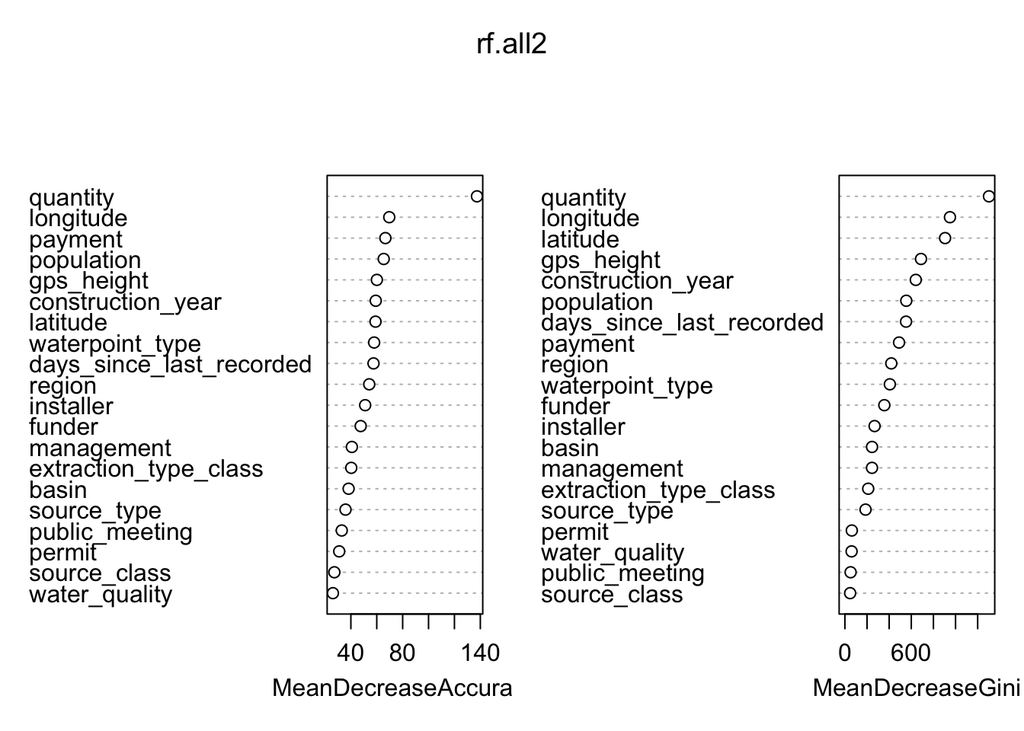

```r
# train/test split
set.seed(1234)
sample <- sample.split(finalWP$status_group, SplitRatio = .7)
train <- subset(finalWP, sample == TRUE)
test <- subset(finalWP, sample == FALSE)

# Commented for notebook efficiency:
# Tuning Randomforest for optimal mtry parameter
#rf.all.tune <- tuneRF(finalWP[,-19], finalWP[,19], ntreeTry=800, stepFactor=1.5)

# Randomforest 2
set.seed(12345)
rf.all2 <- randomForest(status_group ~ .-id, mtry=4,ntree = 350,data=train,importance=TRUE)

varImpPlot(rf.all2)
```

```r
yhat.rf2 <- predict(rf.all2 ,newdata=test,type = "response")

confusionMatrix(test$status_group,yhat.rf2)
```

```
## Confusion Matrix and Statistics
##
##                          Reference
## Prediction                functional functional needs repair
##   functional                    3944                      94
##   functional needs repair        289                     185
##   non functional                 470                      43
##                          Reference
## Prediction                non functional
##   functional                         283
##   functional needs repair             77
##   non functional                    2104
##
## Overall Statistics
##
##                Accuracy : 0.8323
##                  95% CI : (0.8236, 0.8407)
##     No Information Rate : 0.628
##     P-Value [Acc > NIR] : < 2.2e-16
##
##                   Kappa : 0.6772
##  Mcnemar's Test P-Value : < 2.2e-16
##
## Statistics by Class:
##
##                      Class: functional Class: functional needs repair
## Sensitivity                     0.8386                        0.57453
## Specificity                     0.8647                        0.94893
## Pos Pred Value                  0.9128                        0.33575
## Neg Pred Value                  0.7604                        0.98025
## Prevalence                      0.6280                        0.04300
## Detection Rate                  0.5266                        0.02470
## Detection Prevalence            0.5770                        0.07357
## Balanced Accuracy               0.8516                        0.76173
##                      Class: non functional
## Sensitivity                         0.8539
## Specificity                         0.8979
## Pos Pred Value                      0.8040
## Neg Pred Value                      0.9261
## Prevalence                          0.3290
## Detection Rate                      0.2809
## Detection Prevalence                0.3494
## Balanced Accuracy                   0.8759
```